# A Linear Analysis on Flight Delays

Daniel OCallaghan

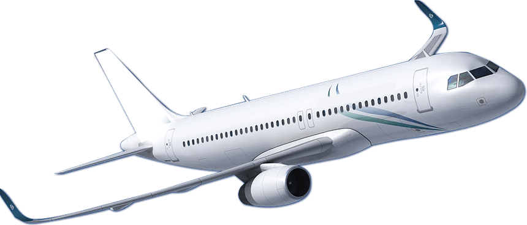

A presentation to demonstrate knowledge of HTML Presentations

# Table Of Contents

- A Discussion on what we will be looking at
  - A brief look at the table
  - Summary Statistics for the Necessary Variables
- Looking at the slope and graph for each linear model
  - Delayed Flight vs Minutes of Late Arrival
  - Delayed Flight vs Bagging Time
  - Delayed Flight vs Time in security
- Conclusions
  - Which had the highest slope?
  - Which had the highest correlation

# Discussion

- We want to take a look at 3 different variables and see how they affect arrival time.
- Specifically we will be looking at how Flight Delay interacts with
  - Late Arrival Time (in minutes)
  - Baggage Loading Time (in minutes)
  - Time in Security (in minutes)

# Insight into data

|  | Baggage_loading_time | Late_Arrival_o | Security_o | Arr_Delay |
| --- | --- | --- | --- | --- |
| 1 | 17 | 19 | 31 | 58 |
| 2 | 17 | 19 | 32 | 48 |
| 3 | 16 | 17 | 29 | 16 |
| 4 | 18 | 19 | 31 | 81 |
| 5 | 17 | 19 | 37 | 62 |
| 6 | 16 | 19 | 31 | 34 |
| 7 | 16 | 19 | 39 | 63 |
| 8 | 17 | 18 | 39 | 47 |
| 9 | 17 | 19 | 53 | 39 |
| 10 | 18 | 19 | 36 | 122 |

[output cut: 3583 more lines]

# Summary Statistics for Arrival Time

|  | Baggage_loading_time | Late_Arrival_o | Security_o | Arr_Delay |
| --- | --- | --- | --- | --- |
|  | Min. :14.00 | Min. :15.00 | Min. :13.00 | Min. : 0.0 |
|  | 1st Qu.:17.00 | 1st Qu.:18.00 | 1st Qu.:32.00 | 1st Qu.: 49.0 |
|  | Median :17.00 | Median :19.00 | Median :37.00 | Median : 70.0 |
|  | Mean :16.98 | Mean :18.74 | Mean :37.09 | Mean : 69.8 |
|  | 3rd Qu.:17.00 | 3rd Qu.:19.00 | 3rd Qu.:42.00 | 3rd Qu.: 90.0 |
|  | Max. :19.00 | Max. :22.00 | Max. :63.00 | Max. :180.0 |

# Linear Analyses

# Delayed Flight vs Late Arrival

- In this relationship, our flight Delay will increase by 24.56196 minutes for every 1 minute increase in Late Arrival. This relationship has a correlation of 0.66684

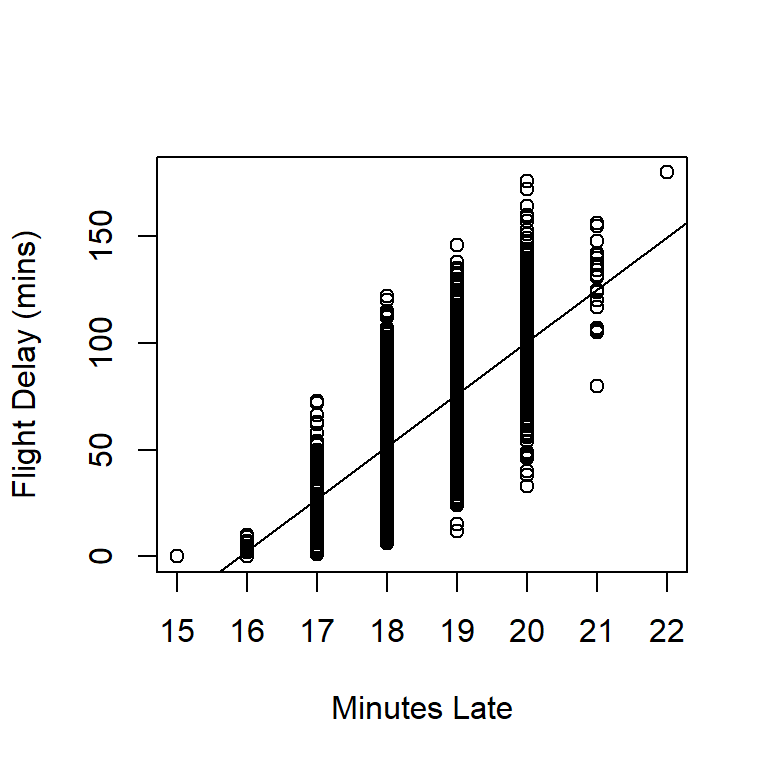

# Delayed Flight vs Baggage Time

- In this relationship, Flight Delay increases by 33.54257 minutes for every 1 minute increase in baggage loading time

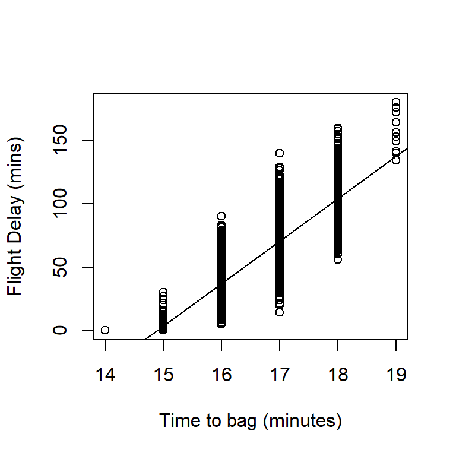

# Delayed Flight vs Security Time

- As seen Below, time in security has no linear relationship with a Delayed Flight

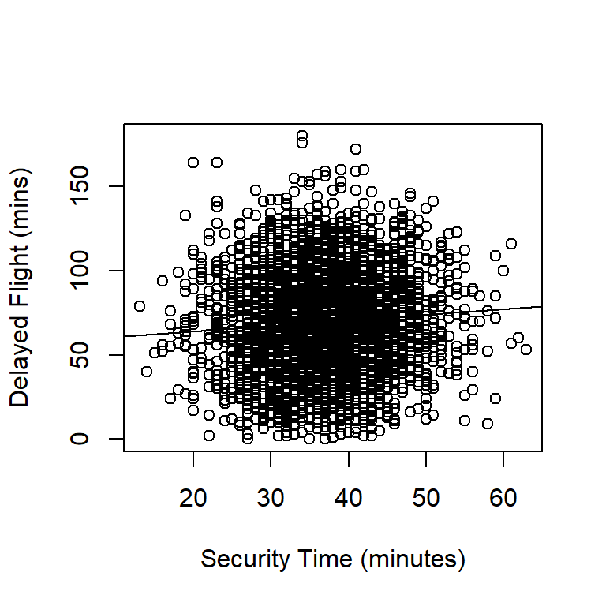

# Conclusions